# Библиотека Pandas

Библиотека Pandas предоставляет множество операций работы с данными, обычно реализуемых электронными таблицами и базами данных.

В Pandas реализованы два основных типа данных:

```
- Series - одномерным массив индексированных данных
- DataFrame - многомерный массив с метками для строк и столбцов, а также, зачастую, неоднородным типом данных и пропущенными значениями
```

```python
import pandas as pd
```

#### Создание набора данных

```python
names = ['Петров Вася', 'Иванов Петя', 'Смирнов Ваня', 'Орлова Люба', 'Круглова Даша']
matem = [4,5,3,4,5]
inform = [5,5,4,4,5]
PupilDataSet = list(zip(names, matem, inform))
```

```python
PupilDataSet
```

```
[('Петров Вася', 4, 5),
 ('Иванов Петя', 5, 5),
 ('Смирнов Ваня', 3, 4),
 ('Орлова Люба', 4, 4),
 ('Круглова Даша', 5, 5)]
```

Создание DataFrame на основе списка строк таблицы

```python
df = pd.DataFrame(data = PupilDataSet, columns = ['Фамилия, имя', 'математика', 'информатика'])
df
```

|  | Фамилия, имя | математика | информатика |
| --- | --- | --- | --- |
| 0 | Петров Вася | 4 | 5 |
| 1 | Иванов Петя | 5 | 5 |
| 2 | Смирнов Ваня | 3 | 4 |
| 3 | Орлова Люба | 4 | 4 |
| 4 | Круглова Даша | 5 | 5 |

Создание DataFrame на основе списка словарей

```python
df1 = pd.DataFrame([{'Фамилия, имя': 'Сидоров Петя', 'математика': 5, 'информатика': 4}], index=[len(df)])
```

Добавление новых данных в таблицу

```python
df = pd.concat([df, df1])
```

```python
df
```

|  | Фамилия, имя | математика | информатика |
| --- | --- | --- | --- |
| 0 | Петров Вася | 4 | 5 |
| 1 | Иванов Петя | 5 | 5 |
| 2 | Смирнов Ваня | 3 | 4 |
| 3 | Орлова Люба | 4 | 4 |
| 4 | Круглова Даша | 5 | 5 |
| 5 | Сидоров Петя | 5 | 4 |

#### Сохранение и загрузка данных

**pd.read_csv()** - чтение из формата CSV

**pd.read_excel()** - чтение из формата MS Excel

**pd.to_csv()** - запись в формата CSV

**pd.to_excel()** - запись в формат MS Excel

```python
df.to_csv('pupils7A.csv', index=False, header=False)
```

```python
df.to_excel('pupils7A.xlsx', index=False)
```

```python
df = pd.read_csv('pupils7A.csv', header = None)
```

```python
df
```

|  | 0 | 1 | 2 |
| --- | --- | --- | --- |
| 0 | Петров Вася | 4 | 5 |
| 1 | Иванов Петя | 5 | 5 |
| 2 | Смирнов Ваня | 3 | 4 |
| 3 | Орлова Люба | 4 | 4 |
| 4 | Круглова Даша | 5 | 5 |
| 5 | Сидоров Петя | 5 | 4 |

Переопределение названий столбцов

```python
df.columns = ['Фамилия, имя', 'математика', 'информатика']
```

```python
df
```

|  | Фамилия, имя | математика | информатика |
| --- | --- | --- | --- |
| 0 | Петров Вася | 4 | 5 |
| 1 | Иванов Петя | 5 | 5 |
| 2 | Смирнов Ваня | 3 | 4 |
| 3 | Орлова Люба | 4 | 4 |
| 4 | Круглова Даша | 5 | 5 |
| 5 | Сидоров Петя | 5 | 4 |

```python
df = pd.read_excel('pupils7A.xlsx')
```

```python
df
```

|  | Фамилия, имя | математика | информатика |
| --- | --- | --- | --- |
| 0 | Петров Вася | 4 | 5 |
| 1 | Иванов Петя | 5 | 5 |
| 2 | Смирнов Ваня | 3 | 4 |
| 3 | Орлова Люба | 4 | 4 |
| 4 | Круглова Даша | 5 | 5 |
| 5 | Сидоров Петя | 5 | 4 |

Получение информации о таблице: типы данных, количество строк, наличие пропущенных значений

```python
df.info()
```

```
<class 'pandas.core.frame.DataFrame'>
RangeIndex: 6 entries, 0 to 5
Data columns (total 3 columns):
 #   Column        Non-Null Count  Dtype
---  ------        --------------  -----
 0   Фамилия, имя  6 non-null      object
 1   математика    6 non-null      int64
 2   информатика   6 non-null      int64
dtypes: int64(2), object(1)
memory usage: 276.0+ bytes
```

Простмотр начальных строк таблицы

```python
df.head(4)
```

|  | Фамилия, имя | математика | информатика |
| --- | --- | --- | --- |
| 0 | Петров Вася | 4 | 5 |
| 1 | Иванов Петя | 5 | 5 |
| 2 | Смирнов Ваня | 3 | 4 |
| 3 | Орлова Люба | 4 | 4 |

```python
df[:2]
```

|  | Фамилия, имя | математика | информатика |
| --- | --- | --- | --- |
| 0 | Петров Вася | 4 | 5 |
| 1 | Иванов Петя | 5 | 5 |

Просмотр конечных строк таблицы

```python
df.tail(3)
```

|  | Фамилия, имя | математика | информатика |
| --- | --- | --- | --- |
| 3 | Орлова Люба | 4 | 4 |
| 4 | Круглова Даша | 5 | 5 |
| 5 | Сидоров Петя | 5 | 4 |

```python
df[-2:]
```

|  | Фамилия, имя | математика | информатика |
| --- | --- | --- | --- |
| 4 | Круглова Даша | 5 | 5 |
| 5 | Сидоров Петя | 5 | 4 |

Получение информации о типах данных столбцов таблицы

```python
df.dtypes
```

```
Фамилия, имя    object
математика       int64
информатика      int64
dtype: object
```

#### Обращение к столбцу таблицы

**<имя DataFrame>.<имя столбца>** (этот способ не работает если в неазвании столбца есть пробелы)

**<имя DataFrame>[<имя столбца>]**

```python
df.математика
```

```
0    4
1    5
2    3
3    4
4    5
5    5
Name: математика, dtype: int64
```

```python
df['математика']
```

```
0    4
1    5
2    3
3    4
4    5
5    5
Name: математика, dtype: int64
```

```python
df['Фамилия, имя']
```

```
0      Петров Вася
1      Иванов Петя
2     Смирнов Ваня
3      Орлова Люба
4    Круглова Даша
5     Сидоров Петя
Name: Фамилия, имя, dtype: object
```

```python
df.Фамилия, имя
```

```
---------------------------------------------------------------------------
AttributeError                            Traceback (most recent call last)
Cell In[69], line 1
----> 1 df.Фамилия, имя

File ~\anaconda3\Lib\site-packages\pandas\core\generic.py:5989, in NDFrame.__getattr__(self, name)
   5982 if (
   5983     name not in self._internal_names_set
   5984     and name not in self._metadata
   5985     and name not in self._accessors
   5986     and self._info_axis._can_hold_identifiers_and_holds_name(name)
   5987 ):
   5988     return self[name]
-> 5989 return object.__getattribute__(self, name)

AttributeError: 'DataFrame' object has no attribute 'Фамилия'
```

#### Фильтрация данных

Аналогична фильтрации массивов в Numpy.

В условии задействованы отдельные столбцы, но фильтруется вся таблица.

```python
df[df['математика'] > 3]
```

|  | Фамилия, имя | математика | информатика |
| --- | --- | --- | --- |
| 0 | Петров Вася | 4 | 5 |
| 1 | Иванов Петя | 5 | 5 |
| 3 | Орлова Люба | 4 | 4 |
| 4 | Круглова Даша | 5 | 5 |
| 5 | Сидоров Петя | 5 | 4 |

```python
df[(df['математика'] == 5) & (df['информатика'] == 5) ]
```

|  | Фамилия, имя | математика | информатика |
| --- | --- | --- | --- |
| 1 | Иванов Петя | 5 | 5 |
| 4 | Круглова Даша | 5 | 5 |

```python
df['Фамилия, имя'][(df['математика'] == 5) | (df['информатика'] == 5) ]
```

```
0      Петров Вася
1      Иванов Петя
4    Круглова Даша
5     Сидоров Петя
Name: Фамилия, имя, dtype: object
```

```python
df[['Фамилия, имя', 'информатика']][(df['математика'] == 5) | (df['информатика'] == 5) ]
```

|  | Фамилия, имя | информатика |
| --- | --- | --- |
| 0 | Петров Вася | 5 |
| 1 | Иванов Петя | 5 |
| 4 | Круглова Даша | 5 |
| 5 | Сидоров Петя | 4 |

```python
df1 = df[(df['математика'] == 5) | (df['информатика'] == 5) ]
```

```python
df1
```

|  | Фамилия, имя | математика | информатика |
| --- | --- | --- | --- |
| 0 | Петров Вася | 4 | 5 |
| 1 | Иванов Петя | 5 | 5 |
| 4 | Круглова Даша | 5 | 5 |
| 5 | Сидоров Петя | 5 | 4 |

Создание новых столбцов, значения в которых вычисляются на основе других столбцов текущей строки

```python
df['Сумма баллов'] = df['математика'] + df['информатика']
```

```python
df
```

|  | Фамилия, имя | математика | информатика | Сумма баллов |
| --- | --- | --- | --- | --- |
| 0 | Петров Вася | 4 | 5 | 9 |
| 1 | Иванов Петя | 5 | 5 | 10 |
| 2 | Смирнов Ваня | 3 | 4 | 7 |
| 3 | Орлова Люба | 4 | 4 | 8 |
| 4 | Круглова Даша | 5 | 5 | 10 |
| 5 | Сидоров Петя | 5 | 4 | 9 |

Сортировка таблицы

```python
sorted_values = df.sort_values(['Сумма баллов'], ascending=False)
```

```python
sorted_values
```

|  | Фамилия, имя | математика | информатика | Сумма баллов |
| --- | --- | --- | --- | --- |
| 1 | Иванов Петя | 5 | 5 | 10 |
| 4 | Круглова Даша | 5 | 5 | 10 |
| 0 | Петров Вася | 4 | 5 | 9 |
| 5 | Сидоров Петя | 5 | 4 | 9 |
| 3 | Орлова Люба | 4 | 4 | 8 |
| 2 | Смирнов Ваня | 3 | 4 | 7 |

Изменение индекса таблицы

```python
sorted_values.set_index(pd.Index(list('abcdef')))
```

|  | Фамилия, имя | математика | информатика | Сумма баллов |
| --- | --- | --- | --- | --- |
| a | Иванов Петя | 5 | 5 | 10 |
| b | Круглова Даша | 5 | 5 | 10 |
| c | Петров Вася | 4 | 5 | 9 |
| d | Сидоров Петя | 5 | 4 | 9 |
| e | Орлова Люба | 4 | 4 | 8 |
| f | Смирнов Ваня | 3 | 4 | 7 |

Агрегатные функции:

- **sum()** - сумма
- **mean()** - среднее арифметическое
- **median()** - медиана
- **min()** - минимум
- **max()** - максимум
- **argmin()** - номер строки минимума
- **argmaх()** - номер строки максимума

```python
max_summa = df['Сумма баллов'].max()
```

```python
max_summa
```

[output not shown]

```python
df['Фамилия, имя'][df['Сумма баллов'] == df['Сумма баллов'].max()]
```

```
1      Иванов Петя
4    Круглова Даша
Name: Фамилия, имя, dtype: object
```

```python
df
```

|  | Фамилия, имя | математика | информатика | Сумма баллов |
| --- | --- | --- | --- | --- |
| 0 | Петров Вася | 4 | 5 | 9 |
| 1 | Иванов Петя | 5 | 5 | 10 |
| 2 | Смирнов Ваня | 3 | 4 | 7 |
| 3 | Орлова Люба | 4 | 4 | 8 |
| 4 | Круглова Даша | 5 | 5 | 10 |
| 5 | Сидоров Петя | 5 | 4 | 9 |

Визуализация данных

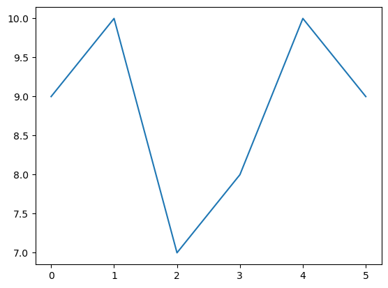

```python
df['Сумма баллов'].plot()
```

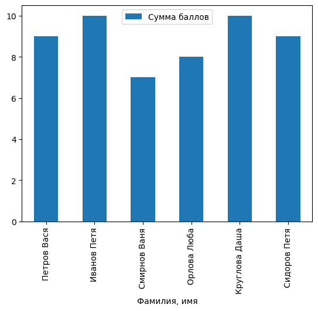

```python
df.plot(kind='bar', x='Фамилия, имя', y='Сумма баллов')
```

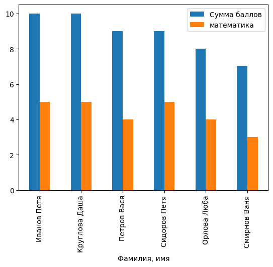

```python
sorted_values.plot.bar(x='Фамилия, имя', y=['Сумма баллов', 'математика']);
```

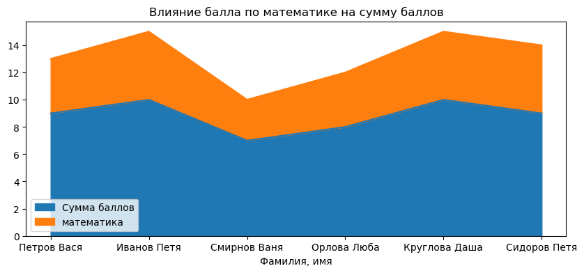

```python
df.plot(kind='area', x='Фамилия, имя', y=['Сумма баллов', 'математика'],
        figsize=(10, 4), title="Влияние балла по математике на сумму баллов");
```

Генерация случайного набора данных

```python
import random
```

```python
candidates = ["Путин", 'Зюганов', 'Мишустин', 'Греф', 'Кириенко']
random.seed(500)
random_names = [candidates[random.randint(0, 4)] for i in range(10000)]
```

```python
random_names[:10]
```

```
['Греф',
 'Кириенко',
 'Кириенко',
 'Греф',
 'Мишустин',
 'Греф',
 'Зюганов',
 'Путин',
 'Мишустин',
 'Кириенко']
```

```python
random_names[-5:]
```

```
['Греф', 'Мишустин', 'Путин', 'Зюганов', 'Греф']
```

```python
df1 = pd.DataFrame(random_names, columns = ['name'])
```

```python
df1.head(5)
```

|  | name |
| --- | --- |
| 0 | Греф |
| 1 | Кириенко |
| 2 | Кириенко |
| 3 | Греф |
| 4 | Мишустин |

Создание столбца с константным значением

```python
df1['Количество голосов'] = 1
```

```python
df1.tail(5)
```

|  | name | Количество голосов |
| --- | --- | --- |
| 9995 | Греф | 1 |
| 9996 | Мишустин | 1 |
| 9997 | Путин | 1 |
| 9998 | Зюганов | 1 |
| 9999 | Греф | 1 |

#### Группировка данных

```python
name = df1.groupby('name').count()
```

```python
name
```

| name | Количество голосов |
| --- | --- |
| Греф | 2011 |
| Зюганов | 1936 |
| Кириенко | 2035 |
| Мишустин | 2030 |
| Путин | 1988 |

```python
name = df1.groupby('name').sum()
```

```python
name
```

| name | Количество голосов |
| --- | --- |
| Греф | 2011 |
| Зюганов | 1936 |
| Кириенко | 2035 |
| Мишустин | 2030 |
| Путин | 1988 |

Универсальный способ группировки с вычислением агрегатных функций

**<Имя DataFrame>.groupby(<Столбцы группировки>, as_index=False).agg({<Имя столбца>:<Имена агрегатных функций>})**

```python
df1.groupby('name', as_index=False).agg({'Количество голосов':'sum'})
```

|  | name | Количество голосов |
| --- | --- | --- |
| 0 | Греф | 2011 |
| 1 | Зюганов | 1936 |
| 2 | Кириенко | 2035 |
| 3 | Мишустин | 2030 |
| 4 | Путин | 1988 |

```python
df.groupby('математика', as_index=False).agg({'Фамилия, имя':'count'})
```

|  | математика | Фамилия, имя |
| --- | --- | --- |
| 0 | 3 | 1 |
| 1 | 4 | 2 |
| 2 | 5 | 3 |

```python
df.groupby(['математика', 'Сумма баллов'], as_index=False).agg({'Фамилия, имя':'count'})
```

|  | математика | Сумма баллов | Фамилия, имя |
| --- | --- | --- | --- |
| 0 | 3 | 7 | 1 |
| 1 | 4 | 8 | 1 |
| 2 | 4 | 9 | 1 |
| 3 | 5 | 9 | 1 |
| 4 | 5 | 10 | 2 |

```python
df.groupby('Сумма баллов', as_index=False).agg({'математика':['max', 'min']})
```

|  | Сумма баллов | математика max | математика min |
| --- | --- | --- | --- |
| 0 | 7 | 3 | 3 |
| 1 | 8 | 4 | 4 |
| 2 | 9 | 5 | 4 |
| 3 | 10 | 5 | 5 |

```python
df.groupby('Сумма баллов', as_index=False).agg({'математика':['max', 'min'], 'информатика':['max', 'min']})
```

|  | Сумма баллов | математика max | математика min | информатика max | информатика min |
| --- | --- | --- | --- | --- | --- |
| 0 | 7 | 3 | 3 | 4 | 4 |
| 1 | 8 | 4 | 4 | 4 | 4 |
| 2 | 9 | 5 | 4 | 5 | 4 |
| 3 | 10 | 5 | 5 | 5 | 5 |